# Compte rendu TP4 - tests statistiques - ANOVA

# ANOVA à 2 facteurs (les facteurs sont “engrais” et “température”) → H0 : “les moyennes des différents groupes sont égales”

##. Modèle d’ANOVA où l’on teste l’effet de 2 facteurs ainsi que leur interaction

```r
model1 <- aov(croissance$hauteur~croissance$temperature*croissance$engrais)
summary(model1)
```

```
##                                           Df Sum Sq Mean Sq F value   Pr(>F)
## croissance$temperature                     1  370.6   370.6  41.852 3.07e-05
## croissance$engrais                         1    0.6     0.6   0.064    0.805
## croissance$temperature:croissance$engrais  1   60.1    60.1   6.784    0.023
## Residuals                                 12  106.2     8.9
##
## croissance$temperature                    ***
## croissance$engrais
## croissance$temperature:croissance$engrais *
## Residuals
## ---
## Signif. codes:  0 '***' 0.001 '**' 0.01 '*' 0.05 '.' 0.1 ' ' 1
```

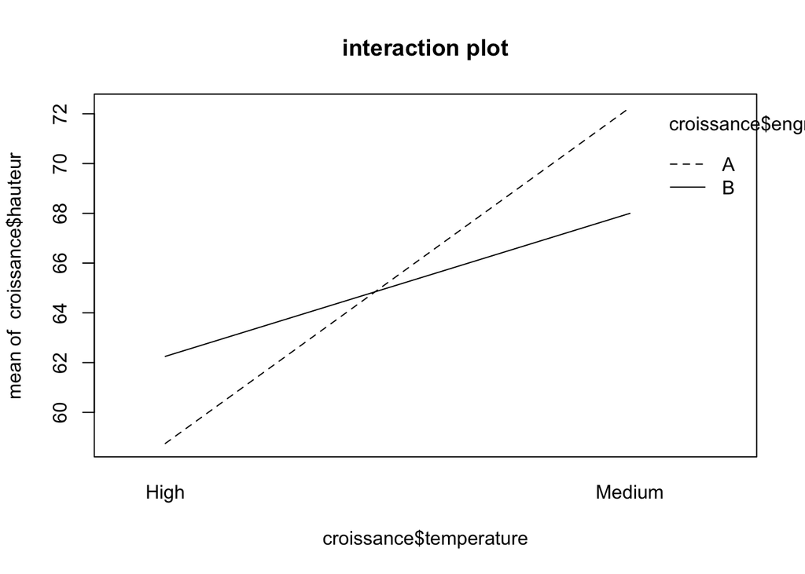

```r
interaction.plot(croissance$temperature, croissance$engrais, croissance$hauteur, main="interaction plot")
```

On trouve une p-value de 3.07e-05.

## Modèle d’ANOVA où l’on teste l’effet de 2 facteurs sans leur interaction

```r
model2 <- aov(croissance$hauteur~croissance$temperature+croissance$engrais)
summary(model2)
```

```
##                        Df Sum Sq Mean Sq F value   Pr(>F)
## croissance$temperature  1  370.6   370.6  28.965 0.000125 ***
## croissance$engrais      1    0.6     0.6   0.044 0.837163
## Residuals              13  166.3    12.8
## ---
## Signif. codes:  0 '***' 0.001 '**' 0.01 '*' 0.05 '.' 0.1 ' ' 1
```

O trouve une p-value de 0.000125

## Comparaison des 2 modèles avec une ANOVA sur les résidus des 2 modèles

```r
anova(model1, model2)
```

```
## Analysis of Variance Table
##
## Model 1: croissance$hauteur ~ croissance$temperature * croissance$engrais
## Model 2: croissance$hauteur ~ croissance$temperature + croissance$engrais
##   Res.Df    RSS Df Sum of Sq      F  Pr(>F)
## 1     12 106.25
## 2     13 166.31 -1   -60.063 6.7835 0.02303 *
## ---
## Signif. codes:  0 '***' 0.001 '**' 0.01 '*' 0.05 '.' 0.1 ' ' 1
```

On trouve une p-value de 0.02303.

On trouve une differnce significative entre ces 2 modeles. Nous allons donc garder le modele car on trouve plus de differneces.

La température influence significativement la hauteur, et l’effet de l’croissance$engrais dépend de la température.

```r
# plantes avec "engrais" différents
t.test(croissance$hauteur[croissance$engrais=="A" & croissance$temperature=="High"], croissance$hauteur[croissance$engrais=="B" & croissance$temperature=="High"], var.equal=T)     # comparaison A/B pour température "High"
```

```
##
##  Two Sample t-test
##
## data:  croissance$hauteur[croissance$engrais == "A" & croissance$temperature == "High"] and croissance$hauteur[croissance$engrais == "B" & croissance$temperature == "High"]
## t = -1.5215, df = 6, p-value = 0.179
## alternative hypothesis: true difference in means is not equal to 0
## 95 percent confidence interval:
##  -9.128784  2.128784
## sample estimates:
## mean of x mean of y
##     58.75     62.25
```

```r
t.test(croissance$hauteur[croissance$engrais=="A" & croissance$temperature=="Medium"], croissance$hauteur[croissance$engrais=="B" & croissance$temperature=="Medium"], var.equal=T) # comparaison A/B pour température "Medium"
```

```
##
##  Two Sample t-test
##
## data:  croissance$hauteur[croissance$engrais == "A" & croissance$temperature == "Medium"] and croissance$hauteur[croissance$engrais == "B" & croissance$temperature == "Medium"]
## t = 2.2517, df = 6, p-value = 0.06529
## alternative hypothesis: true difference in means is not equal to 0
## 95 percent confidence interval:
##  -0.3684448  8.8684448
## sample estimates:
## mean of x mean of y
##     72.25     68.00
```

```r
# plantes avec "températures" différentes
t.test(croissance$hauteur[croissance$engrais=="A" & croissance$temperature=="Medium"], croissance$hauteur[croissance$engrais=="A" & croissance$temperature=="High"], var.equal=T)   # comparaison High/Medium pour l'engrais A
```

```
##
##  Two Sample t-test
##
## data:  croissance$hauteur[croissance$engrais == "A" & croissance$temperature == "Medium"] and croissance$hauteur[croissance$engrais == "A" & croissance$temperature == "High"]
## t = 6.6469, df = 6, p-value = 0.00056
## alternative hypothesis: true difference in means is not equal to 0
## 95 percent confidence interval:
##   8.530299 18.469701
## sample estimates:
## mean of x mean of y
##     72.25     58.75
```

```r
t.test(croissance$hauteur[croissance$engrais=="B" & croissance$temperature=="Medium"], croissance$hauteur[croissance$engrais=="B" & croissance$temperature=="High"], var.equal=T)   # comparaison High/Medium pour l'engrais B
```

```
##
##  Two Sample t-test
##
## data:  croissance$hauteur[croissance$engrais == "B" & croissance$temperature == "Medium"] and croissance$hauteur[croissance$engrais == "B" & croissance$temperature == "High"]
## t = 2.6441, df = 6, p-value = 0.03833
## alternative hypothesis: true difference in means is not equal to 0
## 95 percent confidence interval:
##   0.4287871 11.0712129
## sample estimates:
## mean of x mean of y
##     68.00     62.25
```

# Production laitiere

```
##   prod_lait      race
## 1      20.1 Abondance
## 2      19.8 Abondance
## 3      21.3 Abondance
## 4      20.7 Abondance
## 5      22.6 Bearnaise
## 6      24.1 Bearnaise
```

Lecture du fichier

```
##
## Abondance Bearnaise Jersiaise
##         4         7         5
```

Races des vaches

```
## Abondance Bearnaise Jersiaise
##    20.475    23.400    31.460
```

La moyenne de production de lait par race de vache.

```
## $Abondance
##    Min. 1st Qu.  Median    Mean 3rd Qu.    Max.
##   19.80   20.02   20.40   20.48   20.85   21.30
##
## $Bearnaise
##    Min. 1st Qu.  Median    Mean 3rd Qu.    Max.
##   22.50   22.75   23.40   23.40   23.95   24.50
##
## $Jersiaise
##    Min. 1st Qu.  Median    Mean 3rd Qu.    Max.
##   31.00   31.20   31.40   31.46   31.60   32.10
```

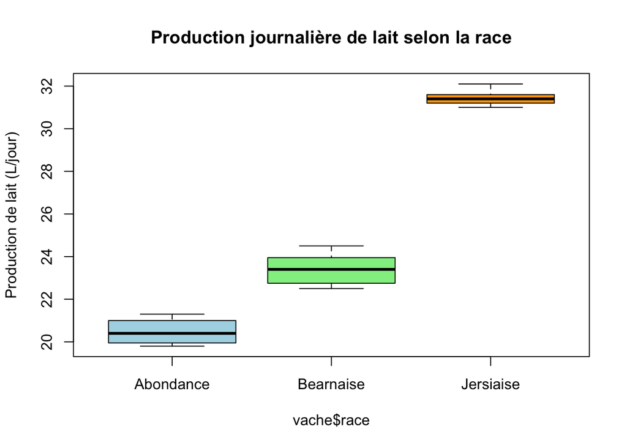

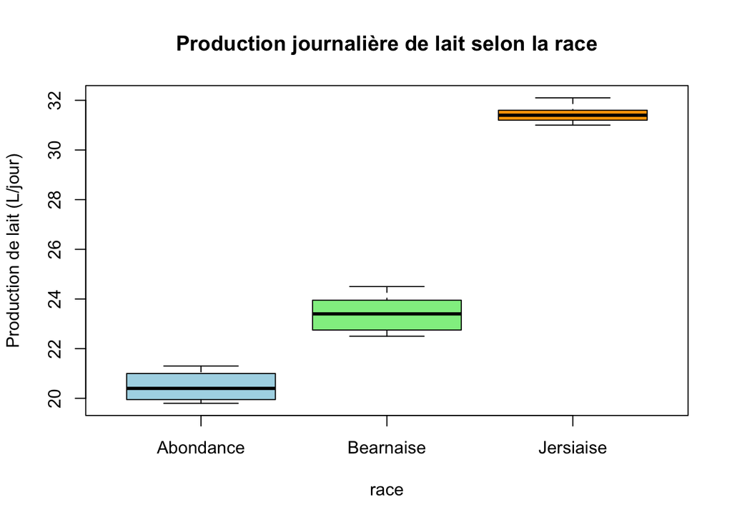

## Tests préalables à l’ANOVA

Normalité (test de Shapiro-Wilk par race) H0 : les données suivent une loi normale dans chaque groupe.

```
## vache$race: Abondance
##
##  Shapiro-Wilk normality test
##
## data:  dd[x, ]
## W = 0.96307, p-value = 0.7982
##
## ------------------------------------------------------------
## vache$race: Bearnaise
##
##  Shapiro-Wilk normality test
##
## data:  dd[x, ]
## W = 0.9384, p-value = 0.6243
##
## ------------------------------------------------------------
## vache$race: Jersiaise
##
##  Shapiro-Wilk normality test
##
## data:  dd[x, ]
## W = 0.96208, p-value = 0.8224
```

Les données observées pour chaque race suivent une loi normal.

Homogénéité des variances (test de Bartlett)

```
##
##  Bartlett test of homogeneity of variances
##
## data:  prod_lait by race
## Bartlett's K-squared = 1.3777, df = 2, p-value = 0.5021
```

## ANOVA à 1 facteur (le facteur est race)

```
##             Df Sum Sq Mean Sq F value   Pr(>F)
## race         2  307.9  153.96   357.4 4.34e-12 ***
## Residuals   13    5.6    0.43
## ---
## Signif. codes:  0 '***' 0.001 '**' 0.01 '*' 0.05 '.' 0.1 ' ' 1
```

H0 : les moyennes de production de lait sont les mêmes entre races. On a une p-value < 0.05, cela montre qu’il y’a au moins une race differente.

## Comparaisons multiples si ANOVA significative

Tests de Student par paires (avec correction Bonferroni)

```
##
##  Pairwise comparisons using t tests with pooled SD
##
## data:  vache$prod_lait and vache$race
##
##           Abondance Bearnaise
## Bearnaise 2.4e-05   -
## Jersiaise 6.9e-12   6.2e-11
##
## P value adjustment method: bonferroni
```

On trouve des differences très significatives entre les 3 groupes.

Les trois races de vaches produisent des quantités de lait significativement différentes.

On trouve des differences très significatives entre les 3 groupes.

Les trois races de vaches produisent des quantités de lait significativement différentes.

Les vaches Jersiaise ont une production laitiere significativement plus importante que les vaches Bearnaise et Abondance.

Les vaches Bearnaise ont une porduction laitiere significativement plus importante que les vaches Abondances.

```
##
## Study: res ~ "race"
##
## Duncan's new multiple range test
## for prod_lait
##
## Mean Square Error:  0.4307308
##
## race,  means
##
##           prod_lait       std r        se  Min  Max    Q25  Q50   Q75
## Abondance    20.475 0.6652067 4 0.3281504 19.8 21.3 20.025 20.4 20.85
## Bearnaise    23.400 0.7702813 7 0.2480584 22.5 24.5 22.750 23.4 23.95
## Jersiaise    31.460 0.4219005 5 0.2935067 31.0 32.1 31.200 31.4 31.60
##
## Groups according to probability of means differences and alpha level( 0.05 )
##
## Means with the same letter are not significantly different.
##
##           prod_lait groups
## Jersiaise    31.460      a
## Bearnaise    23.400      b
## Abondance    20.475      c
```